# Math 421 - Midterm

## Instruction

The midterm has two components: the Rmarkdown notebook (html) and the presentation. We will do the presentation in class. Post both the notebook and the presentation on your Github page.

**The notebook:** The notebook should be created using `rmarkdown` (like other assignments). The notebook should have a title. It should have a table of content (TOC form) or in a tab form. The Rmd files of Tab and Toc form are available on the class webpage.

**The Presentation:** Present your results in 5-10 minutes. To make the presentation using Rmarkdown, do the follows:

```
- In Rstudio -> File -> New File -> R markdown

- In the left panel, click to Presentation -> Click OK

- Now you have an Rmarkdown that can be knitted to be a html presentation
```

- You can also use Rmd samples of the class slides that are available on the class webpage.
- You do not need to rerun all the codes for the presentation. For example, to show the model comparison, you just need to show the image of the model comparison instead of running all the models again.
- To inset an image in a slide, use `![](image.png)`
- To scale images, you can follow these below instructions.
  - https://bookdown.org/yihui/rmarkdown-cookbook/figure-size.html
  - http://zevross.com/blog/2017/06/19/tips-and-tricks-for-working-with-images-and-figures-in-r-markdown-documents/
- To turn off message and warning of a code cell, use: `{r, message=FALSE, warning=FALSE}` for the cell.

**What to present**:

- Present Part 2 - Visualization
- Present Question Question 4, 5 and 6 in Part 3.
- Present any errors/challenges you run into and how you fix/overcome them.

**Data:**

The data for the mid-term project is the Rhode Island Department of Health Hospital Discharge Data. Each row of the data presents a patient.

Link: https://drive.google.com/open?id=15QNBf6YYKocK2nNIfpKDer58kQnCPNZJ

## I. Data Wranggling

1. Download the data file `hdd0318cy.sas7bdat`.
2. Use `read_sas` in library `haven` to read the data.

```r
#I added every package we have used so far just in case I need them
library(haven)
library(VIM)
library(ggplot2)
library(tidyverse)
library(knitr)
library(gganimate)
library(gifski)
library(lubridate)
library(knitr)
library(gapminder)
library(dplyr)
library(recipes)
library(caret)
library(rpart)
library(rattle)
library(randomForest)
#df <- read_sas("hdd0318cy.sas7bdat")
```

3. Filter the data to have only patients of the year 2018 (`yod=2018`)

```r
df <- df %>% filter(yod==18)
```

4. Select to work with only following variables:

```r
df <- df %>% select(  "yod", "payfix","pay_ub92","age",
                      "sex","raceethn","provider","moa",
                      "yoa","mod","admtype", "asource" ,
                      "preopday" ,"los", "service" , "icu","ccu",
                      "dispub92", "payer"  ,"drg","trandb",
                      "randbg","randbs","orr", "anes","seq",
                      "lab","dtest", "ther","blood","phar",
                      "other","patcon","bwght","total","tot" ,
                      "ecodub92","b_wt","pt_state","diag_adm","ancilar" ,
                      "campus","er_fee","er_chrg","er_mode","obs_chrg",
                      "obs_hour","psycchrg","nicu_day")
```

*Notice*: You may want to save the current data to your computer for easy access later. To save the data file use `write_csv(df, 'midterm.csv')`, for example.

```r
#write_csv(df,'midterm.csv')
df <- read_csv('midterm.csv')
```

5. What are variables that have missing values?

```r
colSums(is.na(df))
```

```
##      yod   payfix pay_ub92      age      sex raceethn provider      moa
##        0   131478        0        0        0     3950        0        0
##      yoa      mod  admtype  asource preopday      los  service      icu
##        0        0        1        6    60486        0        0        0
##      ccu dispub92    payer      drg   trandb   randbg   randbs      orr
##        0        0        0        0        0        0        0        0
##     anes      seq      lab    dtest     ther    blood     phar    other
##        0        0        0        0        0        0        0        0
##   patcon    bwght    total      tot ecodub92     b_wt pt_state diag_adm
##        0   131478        0        0   104339        0        3       50
##  ancilar   campus   er_fee  er_chrg  er_mode obs_chrg obs_hour psycchrg
##        0        0        0        0    12158        0    77343        0
## nicu_day
##   124090
```

6. Remove all variables with missing values.

```r
df <- df %>% select(-payfix,-raceethn,-admtype,-asource,-preopday,-bwght,-ecodub92,
                     -pt_state,-diag_adm,-er_mode,-obs_hour,-nicu_day)
colSums(is.na(df))
```

```
##      yod pay_ub92      age      sex provider      moa      yoa      mod
##        0        0        0        0        0        0        0        0
##      los  service      icu      ccu dispub92    payer      drg   trandb
##        0        0        0        0        0        0        0        0
##   randbg   randbs      orr     anes      seq      lab    dtest     ther
##        0        0        0        0        0        0        0        0
##    blood     phar    other   patcon    total      tot     b_wt  ancilar
##        0        0        0        0        0        0        0        0
##   campus   er_fee  er_chrg obs_chrg psycchrg
##        0        0        0        0        0
```

7. Refer to the data description in the file `HDD2015-18cy6-20-19.docx`, which variable recording the month of admission?, which variable recording the month of discharge?

```r
#moa = month of admission
#mod = month of discharge
```

8. Which month admitted the most number of patients? Which month admitted the most number of male patients?

```r
df %>%
  count(moa) %>%
  arrange(-n)
```

```
## # A tibble: 12 × 2
##      moa     n
##    <dbl> <int>
##  1    10 11408
##  2     5 11404
##  3     1 11309
##  4     8 11199
##  5     4 11174
##  6     3 11073
##  7     7 10962
##  8    12 10698
##  9     6 10690
## 10     9 10666
## 11    11 10636
## 12     2 10259
```

```r
#october admits the most patients admitted
```

```r
df %>%
  filter(sex==1) %>%
  count(moa) %>%
  arrange(-n)
```

```
## # A tibble: 12 × 2
##      moa     n
##    <dbl> <int>
##  1    10  5164
##  2     5  5066
##  3     8  5028
##  4     4  4989
##  5     3  4978
##  6     1  4970
##  7     7  4910
##  8    12  4855
##  9     6  4810
## 10    11  4800
## 11     9  4683
## 12     2  4546
```

```r
#october is also the month with the most male patients admitted
```

9. Which month has the most number of teenage female patients?

```r
df %>%
  filter(sex==2 & age < 20) %>%
  count(moa) %>%
  arrange(-n)
```

```
## # A tibble: 12 × 2
##      moa     n
##    <dbl> <int>
##  1     5   868
##  2     1   861
##  3     3   843
##  4    12   828
##  5     9   814
##  6     4   792
##  7    11   792
##  8    10   779
##  9     8   773
## 10     7   735
## 11     2   726
## 12     6   716
```

```r
#may has the most female patients admitted
```

10. Which provider has the most number of female patients in October?

```r
df %>%
  filter(sex==2 & moa == 10) %>%
  count(provider) %>%
  arrange(-n)
```

```
## # A tibble: 12 × 2
##    provider     n
##       <dbl> <int>
##  1     7205  1517
##  2     7214  1224
##  3     7204   872
##  4     7210   699
##  5     7209   351
##  6     7206   333
##  7     7213   317
##  8     7201   294
##  9     7216   256
## 10     7202   212
## 11     7211   122
## 12     7215    46
```

```r
#Rhode Island Hospital has the most female patients admitted in october
```

11. Are female patients older than male patients, on average?

```r
df %>%
  group_by(sex)%>%
  summarize(mean = mean(age))
```

```
## # A tibble: 3 × 2
##     sex  mean
##   <dbl> <dbl>
## 1     1  51.5
## 2     2  50.9
## 3     9  43
```

```r
# no, male patients are older on average
```

12. Calculate the average age of patients by months. Which month has the oldest patients on average age?

```r
df %>%
  group_by(moa) %>%
  summarize(mean = mean(age))
```

```
## # A tibble: 12 × 2
##      moa  mean
##    <dbl> <dbl>
##  1     1  51.8
##  2     2  51.2
##  3     3  51.1
##  4     4  51.4
##  5     5  50.6
##  6     6  51.5
##  7     7  51.3
##  8     8  50.9
##  9     9  50.6
## 10    10  50.8
## 11    11  51.0
## 12    12  51.5
```

```r
#January has the oldest admitted patients on average
```

13. What is the name of the provider that has the highest total charge?

```r
df %>%
  group_by(provider) %>%
  summarise(total_charge = sum(tot)) %>%
  arrange(-total_charge) %>%
  head(5)
```

```
## # A tibble: 5 × 2
##   provider total_charge
##      <dbl>        <dbl>
## 1     7205   1788373499
## 2     7204    678940049
## 3     7214    428480981
## 4     7210    427464111
## 5     7213    240776070
```

```r
#7205 or Rhode Island Hospital charges the most
```

14. What is the name of the provider that has the least total charge for teenage male on average?

```r
df %>%
  filter(age<20 & sex==1)%>%
  group_by(provider) %>%
  summarise(total_charge = sum(tot)) %>%
  arrange(total_charge) %>%
  head(5)
```

```
## # A tibble: 5 × 2
##   provider total_charge
##      <dbl>        <dbl>
## 1     7206        93244
## 2     7211       197425
## 3     7202       646562
## 4     7204       799643
## 5     7213      1239604
```

```r
#7206 or Roger Williams
```

```r
df <- df %>%
  mutate(
    season = case_when(
      moa %in% 9:11 ~ "Fall",
      moa %in% c(12, 1, 2)  ~ "Winter",
      moa %in% 3:5  ~ "Spring",
      TRUE ~ "Summer"))
```

16. On average, how much a 20 year-old male get charged for staying 1 day in the Fall season?

```r
df %>%
  filter(age == 20 & sex == 1 & season == "Fall")%>%
  summarise(one_day = mean(tot)/mean(los))
```

```
## # A tibble: 1 × 1
##   one_day
##     <dbl>
## 1   5915.
```

```r
#an average charge for 1 day for a 20 year old male in Fall is $5,914.60
```

17. Write a paragraph to summarize the section and give your comments on the results. You could do some other calculations to support your points.

```r
#These functions reveal some interesting things about the dataset.
#Personally I am trying to use this data to create a hypothesis of why certain
#demographics might have higher or lower costs than others. For instance, people
#under 30 might have higher average costs because there are less things that should
#be wrong with them in comparison to someone who is older than them, and had more
#time to do damage to their body.
df %>%
  group_by(age)%>%
  summarise(average_charge = mean(tot)) %>%
  arrange(-average_charge)%>%
  head(5)
```

```
## # A tibble: 5 × 2
##     age average_charge
##   <dbl>          <dbl>
## 1    14         51584.
## 2     7         49239.
## 3    13         48191.
## 4    10         44708.
## 5    12         44022.
```

## II. Data Visualization

Continue with the data from part I.

1. Provides at least 10 meaningful plots. Comments on the plots. All plots should have title, caption, appropriate labels on x and y-axis

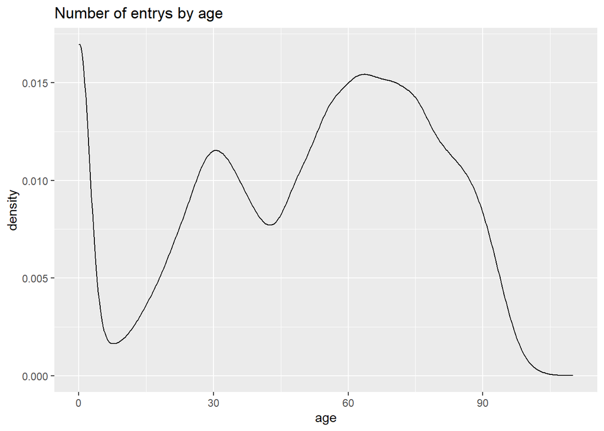

```r
df %>% ggplot()+
  geom_density(mapping = aes(x=age))+
  labs(title = "Number of entrys by age")
```

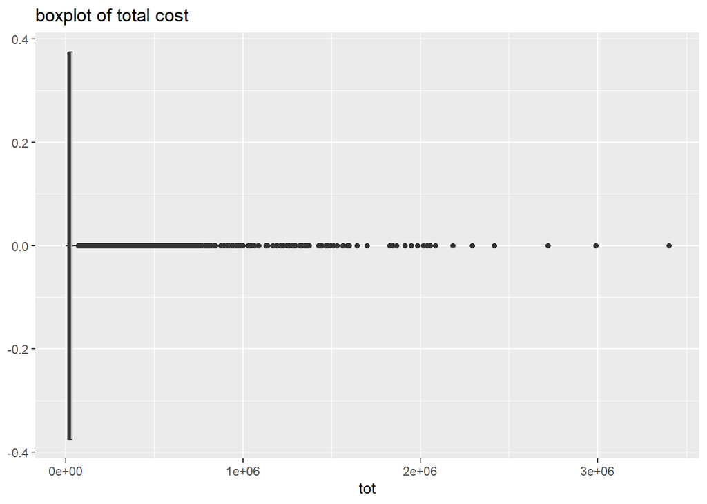

```r
df %>% ggplot()+
  geom_boxplot(mapping = aes(x=tot))+
  labs(title = "boxplot of total cost")
```

```r
#Even though it is not visually informative, I found this interesting because
#of how extreme the outliers are compared to the rest of the data.
```

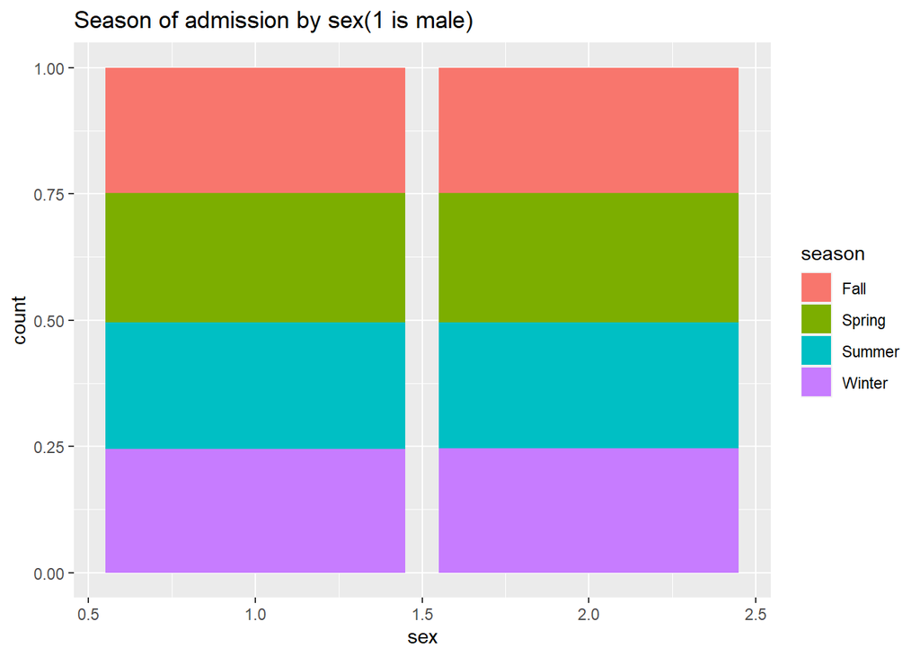

```r
df %>%
  filter(sex == 1|sex == 2) %>%
  ggplot()+
  geom_bar(mapping=aes(x=sex, fill=season), position = 'fill')+
  labs(title = "Season of admission by sex(1 is male)")
```

```r
#I found this interesting because the division by season seemed to have little
#to no impact on either sex's admissions at large
#I also removed the sex=9 value because the data dictionary never specified
#what that is so I cannot derive meaningful results from it
```

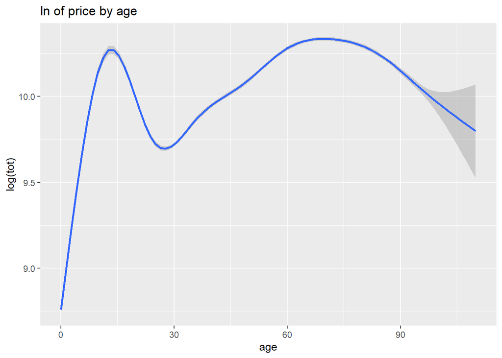

```r
df %>% ggplot()+geom_smooth(aes(x=age, y=log(tot)))+labs(title = "ln of price by age")
```